# Analyzing plate reader and growth data

For analyzing growth data in R, you need two things.

1. To create a “mapping file”. This means a file that tells R what was in what well
2. To read in the raw data you get off the plate reader

### Mapping file and plate map

Let’s see a mapping file first. You can make this in excel or in R. Erica’s plate is really complicated and is a combination of

- two different carbon sources (glucose and glycerol)
- two different strains (code named 1 and 10)
- two different amendments (lysine and a lysine alternative)
- at two different concentrations (0.05 mM and 0.125 mM).

Her plate map looks like this:

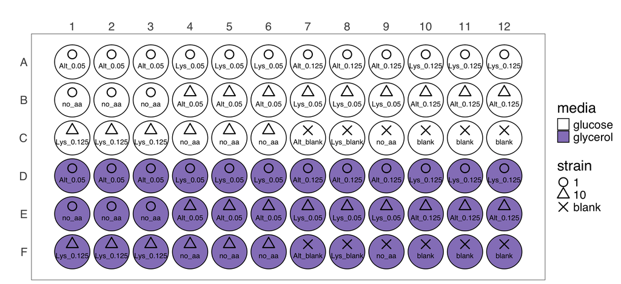

The mapping file needs to contain all of this information. I made mine in R because there are repeating patterns we can take advantage of to reduce the amount of manual typing we have to do. I’m lazy and I like R to do my work for me.

Here’s how I made mine:

```r
library(stringr) #str_split_fixed

#for the labels
label = c(rep(c('Alt_0.05', 'Lys_0.05', 'Alt_0.125', 'Lys_0.125', 'no_aa'), each = 3))
one_media = c(rep(label, times = 2), 'Alt_blank', 'Lys_blank', 'no_aa', rep('blank', each = 3))

#put it all together into a dataframe
mapping <- data.frame(wells = paste(rep(LETTERS[1:6], each = 12), rep(seq(1:12), times = 6), sep = ''),
                      conditions = rep(one_media, times = 2),
                      media = c(rep(c('glucose', 'glycerol'), each = 36)),
                      strain = rep(c(rep(1, each = 15), rep(10, each = 15), rep('blank', each = 6)), times = 2))

#this splits these characters based on '_' two times
mapping$condition_only <- str_split_fixed(mapping$conditions, pattern = '_', n = 2)[,1]
mapping$concentration <- str_split_fixed(mapping$conditions, pattern = '_', n = 2)[,2]

head(mapping[,1:6])
```

```
##   wells conditions   media strain condition_only concentration
## 1    A1   Alt_0.05 glucose      1            Alt          0.05
## 2    A2   Alt_0.05 glucose      1            Alt          0.05
## 3    A3   Alt_0.05 glucose      1            Alt          0.05
## 4    A4   Lys_0.05 glucose      1            Lys          0.05
## 5    A5   Lys_0.05 glucose      1            Lys          0.05
## 6    A6   Lys_0.05 glucose      1            Lys          0.05
```

If this looks overwhelming to you, no problem. You can just make your mapping file in excel and load it into R with `read.delim`, `read.csv`, or `read_excel` depending on the file format.

Now we can move on to loading the plate reader data.

### Loading in clariostar data

Erica has clariostar data. We have the raw excel file that clariostar spits out. There’s a library in R (`readxl`) that can read excel files directly, but we have to tell it the range of excel columns and rows that we want. We only want the actual measurements, not the 5000 lines of metadata that clariostar spits out.

First let’s open the excel file and look at what we’re dealing with.

What is the range of cells we need?

```r
library(readxl) #read_excel function

od <- read_excel('~/Documents/munich/R_Workshop/Growth_curves/data/erica_4.10.24_clariostar_data.xlsx',
                 range = 'B11:CT112')
head(od[,1:4])
```

```
## # A tibble: 6 × 4
##   ...1       A01                 A02                 A03
##   <chr>      <chr>               <chr>               <chr>
## 1 Time       Sample X1           Sample X2           Sample X3
## 2 0 h        0.28100000000000003 0.247               0.28299999999999997
## 3 0 h 30 min 0.28299999999999997 0.25800000000000001 0.27600000000000002
## 4 1 h        0.28000000000000003 0.27100000000000002 0.27600000000000002
## 5 1 h 30 min 0.27200000000000002 0.28899999999999998 0.27400000000000002
## 6 2 h        0.26900000000000002 0.28799999999999998 0.27300000000000002
```

What we loaded in is tragically ugly and quite messy. We need to do further processing before we can use it.

First we can remove the first row. This just contains the sample names, which no one (?) uses anyway.

```r
od <- od[-1,]
head(od[,1:4])
```

```
## # A tibble: 6 × 4
##   ...1       A01                 A02                 A03
##   <chr>      <chr>               <chr>               <chr>
## 1 0 h        0.28100000000000003 0.247               0.28299999999999997
## 2 0 h 30 min 0.28299999999999997 0.25800000000000001 0.27600000000000002
## 3 1 h        0.28000000000000003 0.27100000000000002 0.27600000000000002
## 4 1 h 30 min 0.27200000000000002 0.28899999999999998 0.27400000000000002
## 5 2 h        0.26900000000000002 0.28799999999999998 0.27300000000000002
## 6 2 h 30 min 0.27                0.28599999999999998 0.27600000000000002
```

Looking better! Now we need to change the time into units R can use. 0h 30 min is not useful for plotting. Here we’ll do this using `seq`.

`seq` generates numbers from whatever to whatever by whatever increment. We want it to go from 0 to the last measurement, increasing by 30.

We can find what the final measurement should be by taking the number of rows `nrow(od)` of the data we loaded in, subtract that by one and multiply this number by the time interval. In R speak that equals `(nrow(od) - 1) * 30`

```r
seq(from = 0, to = (nrow(od) - 1) * 30, by = 30)
```

```
##   [1]    0   30   60   90  120  150  180  210  240  270  300  330  360  390  420
##  [16]  450  480  510  540  570  600  630  660  690  720  750  780  810  840  870
##  [31]  900  930  960  990 1020 1050 1080 1110 1140 1170 1200 1230 1260 1290 1320
##  [46] 1350 1380 1410 1440 1470 1500 1530 1560 1590 1620 1650 1680 1710 1740 1770
##  [61] 1800 1830 1860 1890 1920 1950 1980 2010 2040 2070 2100 2130 2160 2190 2220
##  [76] 2250 2280 2310 2340 2370 2400 2430 2460 2490 2520 2550 2580 2610 2640 2670
##  [91] 2700 2730 2760 2790 2820 2850 2880 2910 2940 2970
```

```r
od$time <- seq(from = 0, to = (nrow(od) - 1) * 30, by = 30)
od <- od[,-1] #remove the time column clariostar gave us
```

Now that we have the time fixed we just need to do a little housekeeping. We need to:

1. Change our data into long format. I like to do this with the reshape2 library, and specifically the `melt` function.

```r
library(reshape2) #melt

#reshape and rename columns
od <- melt(od, id.vars = 'time')
head(od)
```

```
##   time variable               value
## 1    0      A01 0.28100000000000003
## 2   30      A01 0.28299999999999997
## 3   60      A01 0.28000000000000003
## 4   90      A01 0.27200000000000002
## 5  120      A01 0.26900000000000002
## 6  150      A01                0.27
```

```r
colnames(od)[2:3] <- c('wells', 'od_value')
```

2. Fix well discrepancy between the mapping file and clariostar data.

```r
od$wells <- gsub(pattern = '([[:alpha:]])0', replacement = '\\1', x = od$wells)
#replace any well that has a letter followed by a number by just the letter
#just turns A01 -> A1 so we can use it as a key with the mapping file
```

3. Convert od values into numeric.

```r
typeof(od$od_value)
```

```
## [1] "character"
```

```r
od$od_value <- as.numeric(od$od_value)
```

4. Move mapping file information to the `od` dataframe

```r
od$cond <- mapping$conditions[match(od$wells, mapping$wells)]
od$media <- mapping$media[match(od$wells, mapping$wells)]
od$strain <- mapping$strain[match(od$wells, mapping$wells)]
```

5. Remove empty wells. Some wells were empty (rows G and H), but the plate-reader took measurements for them anyway.

```r
head(subset(od, select =  grepl(pattern = 'G', x = wells)))
```

```
## data frame with 0 columns and 6 rows
```

```r
#they have NA for all the columns we transferred from the mapping file
od <- na.omit(od) #removes rows containing NA
head(od)
```

```
##   time wells od_value     cond   media strain
## 1    0    A1    0.281 Alt_0.05 glucose      1
## 2   30    A1    0.283 Alt_0.05 glucose      1
## 3   60    A1    0.280 Alt_0.05 glucose      1
## 4   90    A1    0.272 Alt_0.05 glucose      1
## 5  120    A1    0.269 Alt_0.05 glucose      1
## 6  150    A1    0.270 Alt_0.05 glucose      1
```

Now we can actually start to analyze our data.

You might be annoyed that we had to do all these steps just to get our data into a useable format. I am too! When you do things in R that are repetitive and should be done the same way multiple times (ie next time you have plate reader data), the solution is to write a function!

Here’s an example of how we would turn all those steps into a function:

```r
read_plate <- function(measurements, mapping, excel_range){
  df <- read_excel(measurements, range = excel_range)
  df <- df[-1,]
  df$time <- seq(from = 0, to = (nrow(df) - 1) * 30, by = 30)
  df <- df[,-1]
  df <- melt(df, id.vars = 'time')
  colnames(df)[2:3] <- c('wells', 'od_value')
  df$wells <- gsub('([[:alpha:]])0', '\\1', df$wells)
  df$od_value <- as.numeric(df$od_value)
  df$cond <- mapping$conditions[match(df$wells, mapping$wells)]
  df$media <- mapping$media[match(df$wells, mapping$wells)]
  df$strain <- mapping$strain[match(df$wells, mapping$wells)]
  df <- na.omit(df)
  return(df)
}

plate_file = '~/Documents/munich/R_Workshop/Growth_curves/data/erica_4.10.24_clariostar_data.xlsx'
od_function <- read_plate(measurements = plate_file,
                          mapping = mapping,
                          excel_range = 'B11:CT112')
head(od_function)
```

```
##   time wells od_value     cond   media strain
## 1    0    A1    0.281 Alt_0.05 glucose      1
## 2   30    A1    0.283 Alt_0.05 glucose      1
## 3   60    A1    0.280 Alt_0.05 glucose      1
## 4   90    A1    0.272 Alt_0.05 glucose      1
## 5  120    A1    0.269 Alt_0.05 glucose      1
## 6  150    A1    0.270 Alt_0.05 glucose      1
```

Next time I have clariostar data, I can just use this.

However, this function has assumptions built in that can easily cause problems. Do you see any?

### Analyzing blanks

Let’s see what everything looks like first by faceting across the media type and strains.

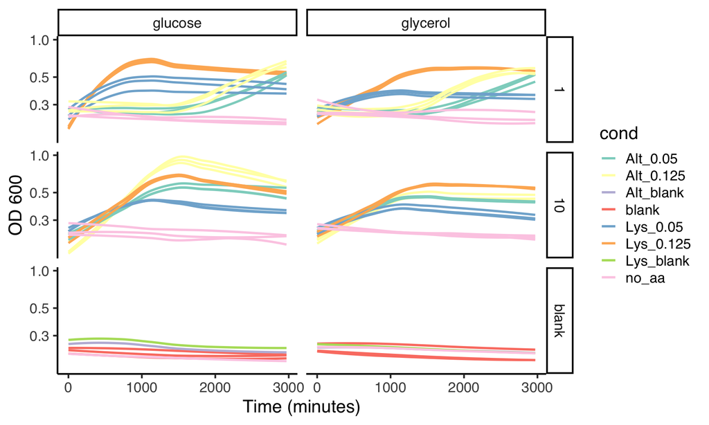

```r
library(RColorBrewer) #brewer color tools
library(ggplot2)

ggplot(od, aes(x = time, y = od_value)) +
  facet_grid(strain~media) +
  geom_smooth(aes(group = wells, color = cond), linewidth = 1.1, se = F) +
  xlab("Time (minutes)") +
  ylab("OD 600") +
  scale_y_log10() +
  scale_color_brewer(palette = 'Set3') +
  theme_classic(base_size = 18, base_family = 'Helvetica')
```

We can see the blanks aren’t really too different from each other, and none are contaminated. Good job Erica! However they do decrease over time due to evaporation. For these exercises I’ll just average them together across each time point, then subtract these values from the experimental wells. Then we can get rid of the blanks.

```r
blanks <- subset(od, strain == 'blank')

blank_vals <- aggregate(od_value ~ time, data = blanks, FUN = mean) #get average of blanks over time
od$blank_avg <- blank_vals$od_value[match(od$time, blank_vals$time)] #transfer to od

od$corrected_od <- od$od_value - od$blank_avg #subtract blanks

od <- subset(od, strain != 'blank') #remove blanks
rm(blanks, blank_vals) #clean up

head(od)
```

```
##   time wells od_value     cond   media strain blank_avg corrected_od
## 1    0    A1    0.281 Alt_0.05 glucose      1 0.2383333   0.04266667
## 2   30    A1    0.283 Alt_0.05 glucose      1 0.2392500   0.04375000
## 3   60    A1    0.280 Alt_0.05 glucose      1 0.2391667   0.04083333
## 4   90    A1    0.272 Alt_0.05 glucose      1 0.2394167   0.03258333
## 5  120    A1    0.269 Alt_0.05 glucose      1 0.2390000   0.03000000
## 6  150    A1    0.270 Alt_0.05 glucose      1 0.2389167   0.03108333
```

### Analyzing and plotting data

Now we can actually get to the fun part, looking at the data and picking whatever weird colors we want.

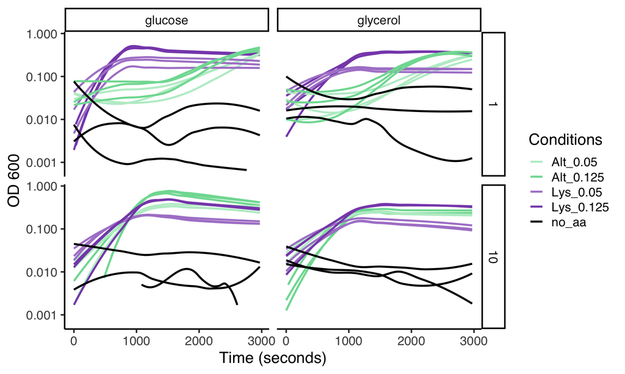

```r
colorz <- c("#BBECCD", "#7fdba1", "#ad85cf", "#884eb9", "black")

#let's take a look
ggplot(od, aes(x = time, y = corrected_od)) +
  facet_grid(strain~media) +
  geom_smooth(aes(group = wells, color = cond), linewidth = 1.1, se = F) +
  xlab("Time (seconds)") +
  ylab("OD 600") +
  scale_color_manual(values = colorz, name = 'Conditions') +
  scale_y_log10() +
  theme_classic(base_size = 18, base_family = 'Helvetica')
```

Alright, so we can see the wells with no amino acids added basically didn’t grow. Checks out. Let’s remove them from further analysis.

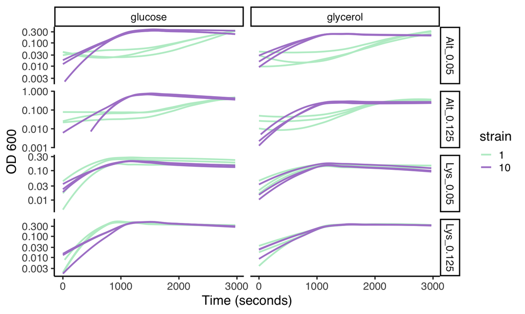

```r
od <- subset(od, cond != 'no_aa')

ggplot(od, aes(x = time, y = corrected_od)) +
  facet_grid(cond~media, scales = 'free_y') +
  geom_smooth(aes(group = wells, color = strain), linewidth = 1.1, se = F) +
  xlab("Time (seconds)") +
  ylab("OD 600") +
  scale_color_manual(values = c("#BBECCD", "#ad85cf")) +
  scale_y_log10() +
  theme_classic(base_size = 18, base_family = 'Helvetica')
```

We can see that the replicates look very similar. Let’s combine them and make error bars.

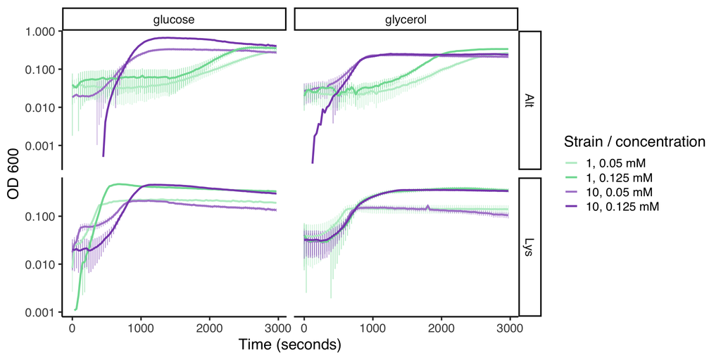

```r
#get mean value for line
mean_val <- aggregate(corrected_od ~ time * paste(cond, media, strain, sep = '_'), data =  od, FUN = mean)
colnames(mean_val)[2] <- c('name')

#get sd for error bars
mean_sd <- aggregate(corrected_od ~ time * paste(cond, media, strain, sep = '_'), od, sd)
colnames(mean_sd)[2] <- c('name')
mean_val$sd <- mean_sd$corrected_od[match(mean_val$name, mean_sd$name)]

#separate out variables
mean_val$media <- str_split_fixed(mean_val$name, '_', 4)[,3]
mean_val$strain <- str_split_fixed(mean_val$name, '_', 4)[,4]
mean_val$cond <- str_split_fixed(mean_val$name, '_', 4)[,1]
mean_val$conc <- str_split_fixed(mean_val$name, '_', 4)[,2]
rm(mean_sd)

ggplot(mean_val, aes(x = time, y = corrected_od)) +
  facet_grid(cond~media, scales = 'free') +
  geom_errorbar(aes(ymin = corrected_od - sd,
                    ymax = corrected_od + sd, color = paste(strain, conc)),
                    width = 0.2, position = position_dodge(width = 0.9), alpha = 0.5) +
  geom_line(aes(group = name, color = paste(strain, conc)), linewidth = 1.1) +
  xlab("Time (seconds)") +
  ylab("OD 600") +
  scale_color_manual(values = colorz, name = 'Strain / concentration',
                     labels = c('1, 0.05 mM', '1, 0.125 mM',
                                '10, 0.05 mM', '10, 0.125 mM')) +
  scale_y_log10() +
  theme_classic(base_size = 18, base_family = 'Helvetica')
```

### Calculating growth rates using growthcurver

R has a nice package (`growthcurver`) for calculating growth rates from plate reader data using the function `SummarizeGrowthByPlate`. If you plan to use it, I recommend checking out their tutorial, found [here.](https://cran.r-project.org/web/packages/growthcurver/vignettes/Growthcurver-vignette.html)

To use growthcurver we need our data to be back in wide format (each well as a column). We can do this using `dcast` from the reshape2 library.

```r
library(growthcurver) #SummarizeGrowthByPlate

#Growthcurver needs time in one column, then one column for each well (wide format)
growth_data <- dcast(data = od, time ~ wells, value.var = 'corrected_od')
growth_data$time <- growth_data$time / 60 #expects hours, not minutes according to help file
head(growth_data[, 1:5])
```

```
##   time         A1           A10           A11          A12
## 1  0.0 0.04266667  0.0006666667 -0.0023333333 -0.015333333
## 2  0.5 0.04375000 -0.0012500000  0.0007500000  0.003750000
## 3  1.0 0.04083333 -0.0041666667  0.0008333333  0.006833333
## 4  1.5 0.03258333 -0.0034166667  0.0025833333  0.007583333
## 5  2.0 0.03000000  0.0010000000  0.0050000000  0.012000000
## 6  2.5 0.03108333  0.0050833333  0.0130833333  0.014083333
```

Now we’re ready to actually run the function to calculate growth rate for each of our wells.

```r
growth_curve <- SummarizeGrowthByPlate(growth_data)
head(growth_curve)
```

```
##   sample            k           n0          r      t_mid      t_gen     auc_l
## 1     A1 3.905457e-01 1.035833e-03 0.13946622  42.516984  4.9700003  3.616822
## 2    A10 4.019554e-01 8.254047e-06 1.53404781   7.035877  0.4518420 17.068678
## 3    A11 3.696443e-01 6.175636e-06 1.55956328   7.053044  0.4444495 15.690270
## 4    A12 4.048973e-01 8.184487e-05 1.26632973   6.717335  0.5473671 17.322521
## 5     A2 4.861303e+06 1.233288e-02 0.06569144 301.291990 10.5515609  4.662492
## 6     A3 3.032465e-01 1.689338e-05 0.22939833  42.700067  3.0215877  2.314141
##       auc_e       sigma note
## 1  3.688958 0.005893504
## 2 17.156083 0.040892327
## 3 15.769083 0.034559353
## 4 17.465583 0.036192938
## 5  4.791333 0.012426681
## 6  2.441333 0.005314285
```

Growthcurver spits out a lot of information, but for our purposes we’re interested in the t_gen (doubling time). It’s very important to look at the note column as well - if the function couldn’t calculate doubling time or had any difficulties you’ll find warnings there.

Let’s plot our doubling times.

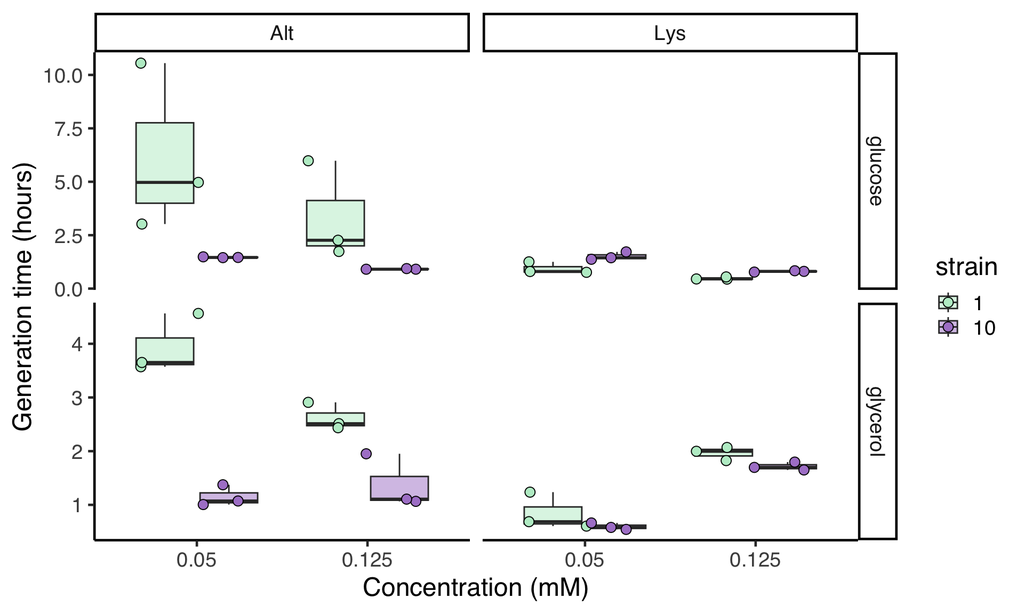

```r
mapping$t_gen <- growth_curve$t_gen[match(mapping$well, growth_curve$sample)]

growth_plot <- subset(mapping, strain != 'blank' & conditions != 'no_aa')

ggplot(growth_plot, aes(x = concentration, y = t_gen, fill = strain)) +
  facet_grid(media ~ condition_only, scales = 'free_y') +
  geom_boxplot(alpha = 0.5, outlier.shape = NA) +
  geom_point(size = 3, pch = 21, position = position_jitterdodge()) +
  ylab('Generation time (hours)') +
  xlab('Concentration (mM)') +
  theme_classic(base_size = 18, base_family = 'Helvetica') +
  scale_fill_manual(values = c("#BBECCD", "#ad85cf"))
```

Alright, looks like strain 10 grows much better on the lysine alternative than strain 1. But is it a significant difference? Let’s seeeee.

### Calculating significance

Using the R package ggsignif we can calculate significance with a t-test directly on our plots. For convenience, I’ll split up the glucose and glycerol results.

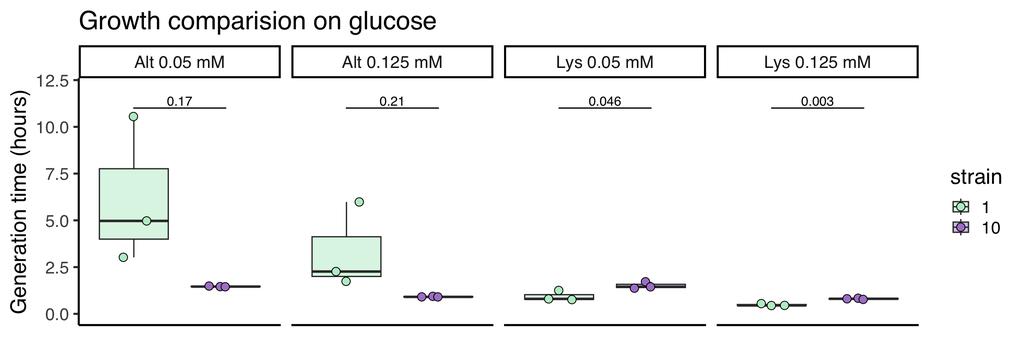

```r
library(ggsignif) #significance

growth_plot$label <- paste(growth_plot$condition_only, ' ', growth_plot$concentration, ' mM', sep = '')
#making a nice looking label

ggplot(subset(growth_plot, media == 'glucose'), aes(x = as.character(strain), y = t_gen, fill = strain)) +
  facet_wrap(~label, nrow = 1) +
  geom_boxplot(alpha = 0.5, outlier.shape = NA) +
  geom_signif(comparisons = list(c('1', '10')), test = 't.test', y_position = 10.5,
              tip_length = 0, family = 'Helvetica') +
  geom_point(size = 3, pch = 21, position = position_jitterdodge()) +
  ggtitle('Growth comparision on glucose') +
  ylab('Generation time (hours)') +
  ylim(c(0, 12)) +
  scale_fill_manual(values = c("#BBECCD", "#ad85cf")) +
  theme_classic(base_size = 18, base_family = 'Helvetica') +
  theme(axis.title.x=element_blank(),
        axis.text.x=element_blank(),
        axis.ticks.x=element_blank())
```

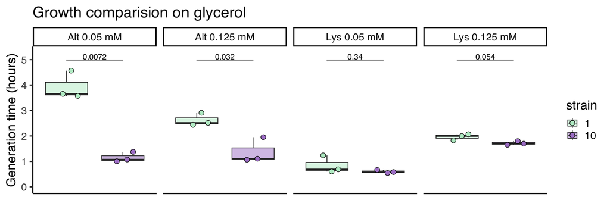

```r
ggplot(subset(growth_plot, media == 'glycerol'), aes(x = as.character(strain), y = t_gen, fill = strain)) +
  facet_grid(~label) +
  geom_boxplot(alpha = 0.5, outlier.shape = NA) +
  geom_signif(comparisons = list(c('1', '10')), test = 't.test', y_position = 4.75,
              tip_length = 0, family = 'Helvetica') +
  geom_point(size = 3, pch = 21, position = position_jitterdodge()) +
  ggtitle('Growth comparision on glycerol') +
  ylab('Generation time (hours)') +
  ylim(c(0, 5.25)) +
  theme_classic(base_size = 18, base_family = 'Helvetica') +
  theme(axis.title.x=element_blank(),
        axis.text.x=element_blank(),
        axis.ticks.x=element_blank()) +
  scale_fill_manual(values = c("#BBECCD", "#ad85cf"))
```

Okay, so we can see that differences in growth rates between the strains are only significant (with the lysine alternative) when the media contains glycerol as the carbon source. Is that interesting scientifically? I don’t know, ask Erica!

`ggsignif` is a flexible package. Siobhan hated that I put the p-values directly on the figure. To turn her frown upside down we can just use significance stars instead.

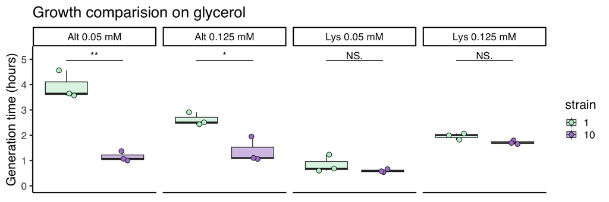

```r
ggplot(subset(growth_plot, media == 'glycerol'), aes(x = as.character(strain), y = t_gen, fill = strain)) +
  facet_grid(~label) +
  geom_boxplot(alpha = 0.5, outlier.shape = NA) +
  geom_signif(comparisons = list(c('1', '10')), test = 't.test', y_position = 4.75,
              tip_length = 0, family = 'Helvetica', map_signif_level=TRUE, textsize = 5) +
  geom_point(size = 3, pch = 21, position = position_jitterdodge()) +
  ggtitle('Growth comparision on glycerol') +
  ylab('Generation time (hours)') +
  ylim(c(0, 5.25)) +
  theme_classic(base_size = 18, base_family = 'Helvetica') +
  theme(axis.title.x=element_blank(),
        axis.text.x=element_blank(),
        axis.ticks.x=element_blank()) +
  scale_fill_manual(values = c("#BBECCD", "#ad85cf"))
```